# Influence of *Alliaria petiolata* on plant community ecology

#### Amelie Mahrt-Smith, Queen’s University

##### Data and supporting documents available on [Github](https://github.com/ameliems99/Metabarcoding).

Garlic mustard, *Alliaria petiolata*, is an invasive species in North America. It was purportedly introduced by European settlers in the 1800s. Current research in the [Colautti Lab](https://www.ecoevogeno.org/research.html) at Queen’s University seeks to identify the effect of this species on native soil ecology, and whether the introduced populations of *A. petiolata* are more vigorous than in its native range. To learn more about garlic mustard, visit the [Opinicon Natural History Blog](https://opinicon.wordpress.com/2020/06/09/garlic-mustard-alliaria-petiolata-brassicaceae/).

This analysis seeks to determine the effect of garlic mustard on plant communities, based on a floristic survey at the Queen’s University Biological Station. More specifically, does the presence of garlic mustard affect plant community composition?

To answer this question, I have chosen to represent the data with a neighbour-joining tree that clusters samples based on the similarity of the plant species present. If garlic mustard has an effect on plant community, we should see distinct clustering of branches based on the presence or absence of garlic mustard in the sample.

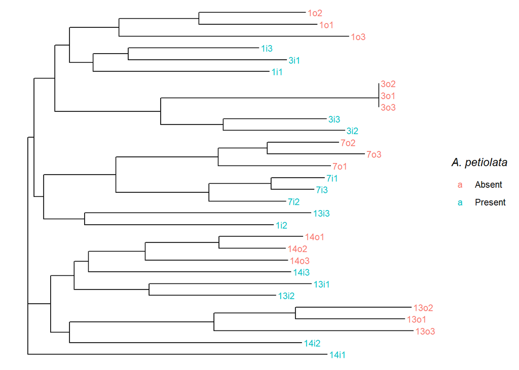

```r
Dat <- read.csv("./Input/FloristicSurvey.csv", header = TRUE)
Dat$Location <- recode(Dat$Location, "i" = "Present", "o" = "Absent")  #is A. petiolata present/absent?
PlDat <- select(Dat, Claytonia_virginiana:maianthenum_racemosum) %>%  #keep plants present in sample
  mutate(Alliaria_petiolata = recode(Dat$Location, "Present" = 1, "Absent" = 0))
row.names(PlDat) <- Dat$ï..Quadrate  #sample IDs

Pl_binary <- PlDat
Pl_binary[Pl_binary > 0] <- 1  #reformat data as presence/absence of a plant species in community
Pl_dist<- dist(Pl_binary, method = 'binary')  #distances btwn communities by species composition
Pl_tree <- nj(Pl_dist)  #neighbour-joining tree
ggtree(Pl_tree, layout = 'rectangular') %<+% Dat +
  geom_tiplab(aes(colour = Location), size = 3) +
  guides(colour = guide_legend(title = expression(italic("A. petiolata"))))
```

**Figure 1.** Clustering of plant communities based on the species present.

Garlic mustard has a weak effect on plant community composition. Fig. 1 shows that there is some clustering of communities by presence or absence of *A. petiolata*. This suggests that for groups of plant communities that are broadly similar, the presence of *A. petiolata* can be used to differentiate between them. However, if *A. petiolata* significantly affected the presence or absence of other species, we would expect to see two distinct clusters of plant communities: an *A. petiolata* present group and an *A. petiolata* absent group.

The floristic survey included abundance of plant species in addition to the community composition, which allows for a more in-depth analysis of the factors affecting plant community structure. For example, what has a stronger effect on plant community: the presence or absence of garlic mustard, or the sampling population?

This question will be analyzed using a non-metric multidimensional scaling approach, represented by a scatterplot of the resulting dimensions. This accounts for the abundance of plant species in addition to the species composition in each community. In this analysis, the communities that have a smaller distance between them are more closely related. The factors that affect community structure can be identified by the clustering of points in relation to those factors.

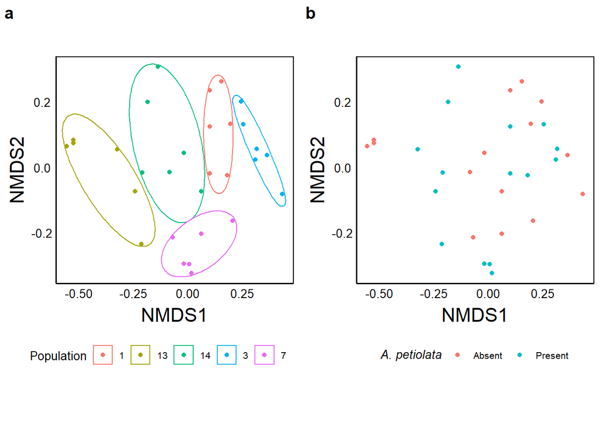

```r
Ab_dist <- vegdist(PlDat, method = 'bray', binary = FALSE)  #Bray-curtis dissimilarity btwn communities
NMDS <- metaMDS(Ab_dist, k = 2)  #non-metric multidimensional scaling, 2 dimensions
PDat <- data.frame(NMDS1 = NMDS$points[, 1],
                   NMDS2 = NMDS$points[, 2],
                   SampleID = Dat$ï..Quadrate,
                   Location = Dat$Location,
                   Population = as.character(Dat$Population))

P1 <- qplot(x = NMDS1, y = NMDS2, colour = Population, data = PDat) +  #colour by sampling pop
  coord_fixed(ratio = 1.5) +  #keep plots square
  theme(legend.position = "bottom") +
  geom_mark_ellipse(aes(color = Population), expand = 0.01) +  #encircle points by population
  theme(legend.justification = "right")
P2 <- qplot(x = NMDS1, y = NMDS2, colour = Location, data = PDat) +  #colour by garlic mustard
  guides(colour = guide_legend(title = expression(italic("A. petiolata")))) +
  coord_fixed(ratio = 1.5) +
  theme(legend.position = "bottom")
plot_grid(P1, P2, labels = c("a", "b"))  #arrange plots in same figure
```

**Figure 2.** (a) The influence of sampling population on the similarity of plant communities. (b) The influence of *A. petiolata* on the similarity of plant communities.